# Human Resource Analysis

Ekta Raj

August 29, 2017

This report explores a dataset containing satisfaction level, salary_level, years spend in the company and other attributes for approximately 15000 human resource working in an organization to discover the factors which are responsible for causing an employee to leave his job.

# Univariate Plots Section

Let’s get aquainted with the underlying dataset.

We have following variables in this dataset.

```
##  [1] "satisfaction_level"    "last_evaluation"
##  [3] "number_project"        "avg_monthly_hours"
##  [5] "time_spend_company"    "Work_accident"
##  [7] "left"                  "promotion_last_5years"
##  [9] "department"            "salary"
## [11] "daily_work_hour"
```

Dimension of the dataset:

```
## [1] 14999    11
```

Dataset looks like this:

```
## # A tibble: 6 x 11
##   satisfaction_level last_evaluation number_project avg_monthly_hours
##                <dbl>           <dbl>          <int>             <int>
## 1               0.38            0.53              2               157
## 2               0.80            0.86              5               262
## 3               0.11            0.88              7               272
## 4               0.72            0.87              5               223
## 5               0.37            0.52              2               159
## 6               0.41            0.50              2               153
## # ... with 7 more variables: time_spend_company <int>,
## #   Work_accident <fctr>, left <fctr>, promotion_last_5years <fctr>,
## #   department <fctr>, salary <ord>, daily_work_hour <dbl>
```

Structure of the dataset:

```
## Classes 'tbl_df', 'tbl' and 'data.frame':    14999 obs. of  11 variables:
##  $ satisfaction_level   : num  0.38 0.8 0.11 0.72 0.37 0.41 0.1 0.92 0.89 0.42 ...
##  $ last_evaluation      : num  0.53 0.86 0.88 0.87 0.52 0.5 0.77 0.85 1 0.53 ...
##  $ number_project       : int  2 5 7 5 2 2 6 5 5 2 ...
##  $ avg_monthly_hours    : int  157 262 272 223 159 153 247 259 224 142 ...
##  $ time_spend_company   : int  3 6 4 5 3 3 4 5 5 3 ...
##  $ Work_accident        : Factor w/ 2 levels "0","1": 1 1 1 1 1 1 1 1 1 1 ...
##  $ left                 : Factor w/ 2 levels "0","1": 2 2 2 2 2 2 2 2 2 2 ...
##  $ promotion_last_5years: Factor w/ 2 levels "0","1": 1 1 1 1 1 1 1 1 1 1 ...
##  $ department           : Factor w/ 10 levels "accounting","hr",..: 8 8 8 8 8 8 8 8 8 8 ...
##  $ salary               : Ord.factor w/ 3 levels "low"<"medium"<..: 1 2 2 1 1 1 1 1 1 1 ...
##  $ daily_work_hour      : num  8 12 13 11 8 7 12 12 11 7 ...
```

Summary of the dataset:

```
##  satisfaction_level last_evaluation  number_project  avg_monthly_hours
##  Min.   :0.0900     Min.   :0.3600   Min.   :2.000   Min.   : 96.0
##  1st Qu.:0.4400     1st Qu.:0.5600   1st Qu.:3.000   1st Qu.:156.0
##  Median :0.6400     Median :0.7200   Median :4.000   Median :200.0
##  Mean   :0.6128     Mean   :0.7161   Mean   :3.803   Mean   :201.1
##  3rd Qu.:0.8200     3rd Qu.:0.8700   3rd Qu.:5.000   3rd Qu.:245.0
##  Max.   :1.0000     Max.   :1.0000   Max.   :7.000   Max.   :310.0
##
##  time_spend_company Work_accident left      promotion_last_5years
##  Min.   : 2.000     0:12830       0:11428   0:14680
##  1st Qu.: 3.000     1: 2169       1: 3571   1:  319
##  Median : 3.000
##  Mean   : 3.498
##  3rd Qu.: 4.000
##  Max.   :10.000
##
##        department      salary     daily_work_hour
##  sales      :4140   low   :7316   Min.   : 5.000
##  technical  :2720   medium:6446   1st Qu.: 8.000
##  support    :2229   high  :1237   Median :10.000
##  IT         :1227                 Mean   : 9.623
##  product_mng: 902                 3rd Qu.:12.000
##  marketing  : 858                 Max.   :15.000
##  (Other)    :2923
```

Our dataset contains eleven variables with approximately 15000 observation.

Let us examine each variable separately.

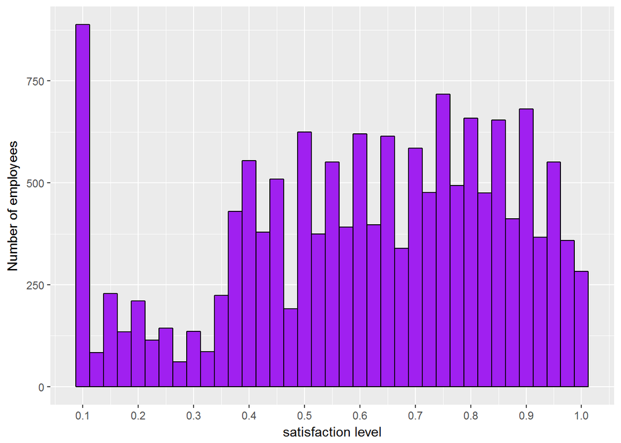

- The above histogram shows the satisfacion level is widely distributed over the scale 0-1.
- Average satisfation level is found to be 0.6128.
- A lot of employees seems to be highly unsatisfied with their job having satisfaction level < 0.4.
- The spikes depicts that most satisfaction levels are in the multiple of 0.05

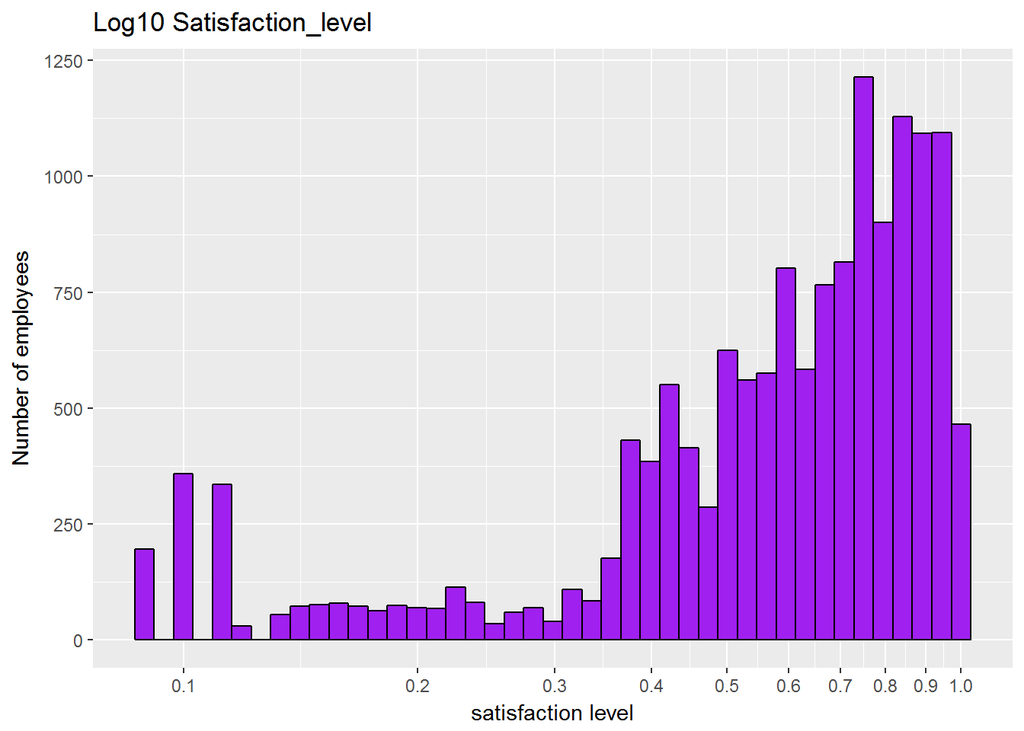

Using log transform over x-axis we get a skewed histogram which shows that most people have satisfaction level more than half.

The summary of satisfaction level is as follows:

```
##    Min. 1st Qu.  Median    Mean 3rd Qu.    Max.
##  0.0900  0.4400  0.6400  0.6128  0.8200  1.0000
```

Proportion of employees having satisfacation level on or above mean is:

```
## [1] 0.5375025
```

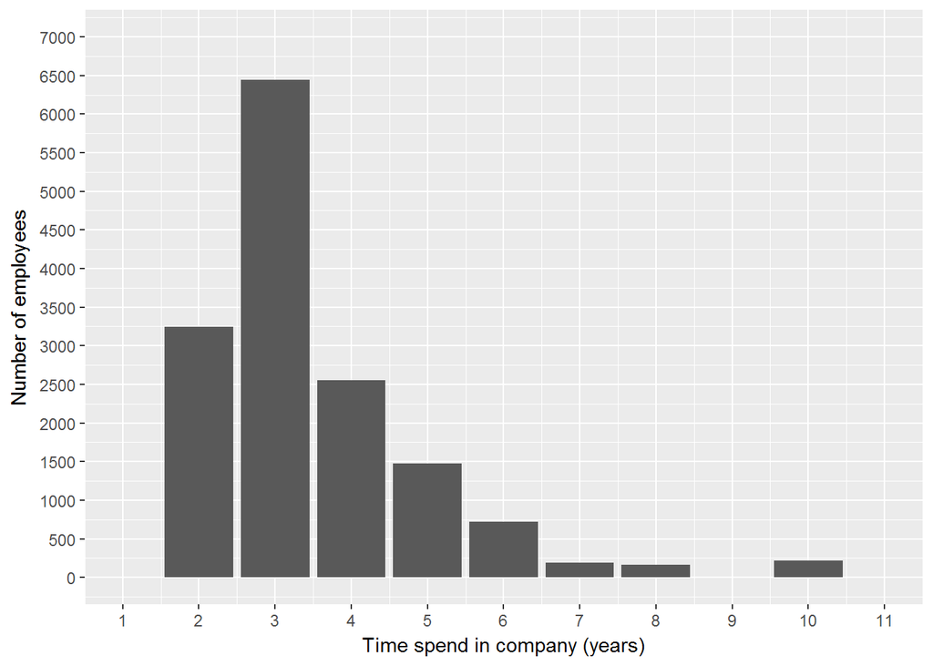

- This plot shows the number of years that people have spent in the company that varies from 2 to 10 years.
- It is clear that most empolyee have spent 3 or more years in the company.
- We can infer that employees have spent atleast a year before moving on. This can also be a result of company’s policy.

```
##    Min. 1st Qu.  Median    Mean 3rd Qu.    Max.
##   2.000   3.000   3.000   3.498   4.000  10.000
```

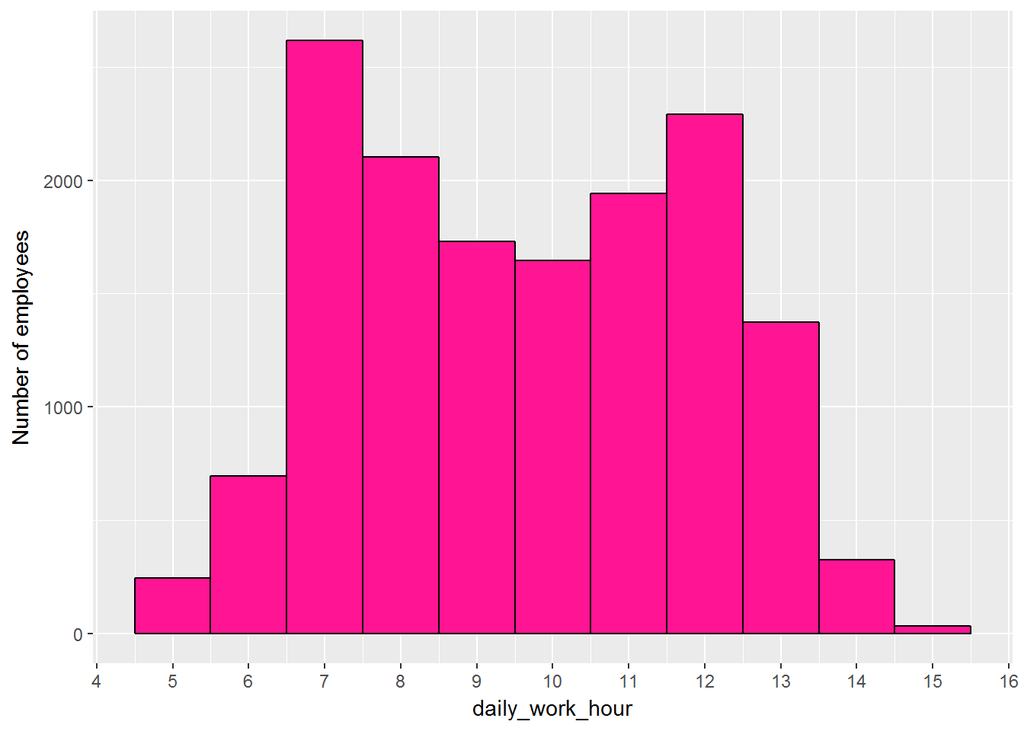

```
##    Min. 1st Qu.  Median    Mean 3rd Qu.    Max.
##   5.000   8.000  10.000   9.623  12.000  15.000
```

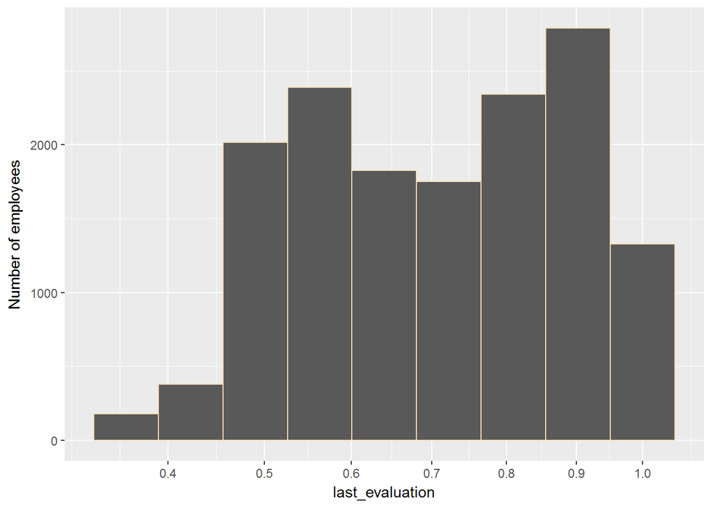

- This plot shows how the employees have performed in their last evalution test, on the scale of 0-1.
- Being a bimodal distribution, it depicts that most people gave average performance scoring around 0.5 and many gave high performance scoring 0.8 and above.

Summary of last evaluation test.

```
##    Min. 1st Qu.  Median    Mean 3rd Qu.    Max.
##  0.3600  0.5600  0.7200  0.7161  0.8700  1.0000
```

Proportion of employees who performed below average is:

```
## [1] 0.4928995
```

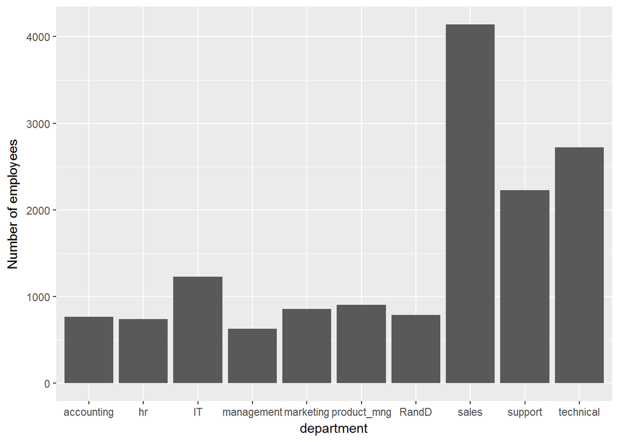

- Considering different departments of an organization we found that sales, support and technical department forms the major part of this oragnisation and IT, marketting, management are among the rest.

```
##  accounting          hr          IT  management   marketing product_mng
##         767         739        1227         630         858         902
##       RandD       sales     support   technical
##         787        4140        2229        2720
```

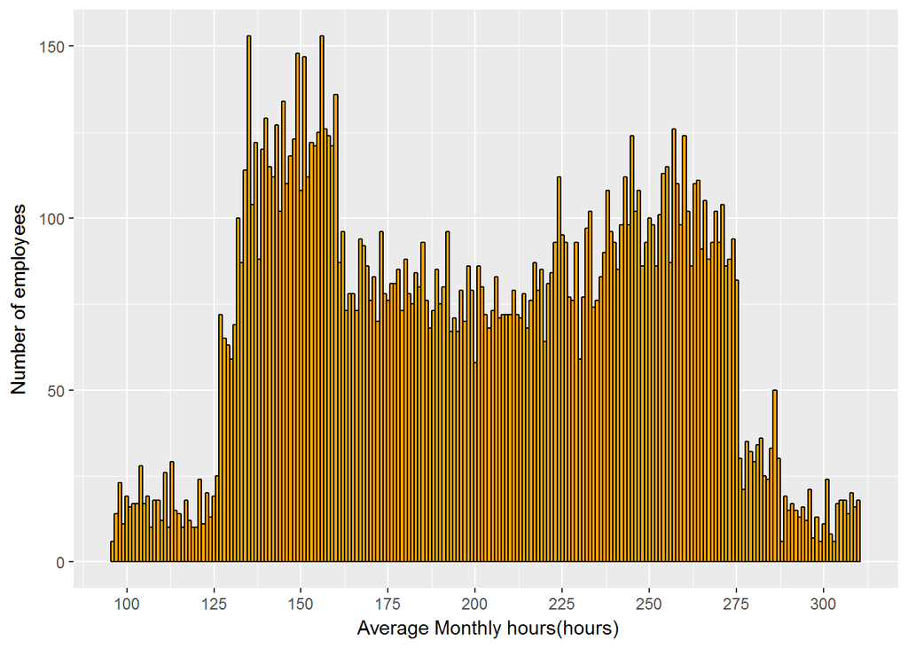

- The plot shows bimodal distribution of average monthly working hours of all employees.

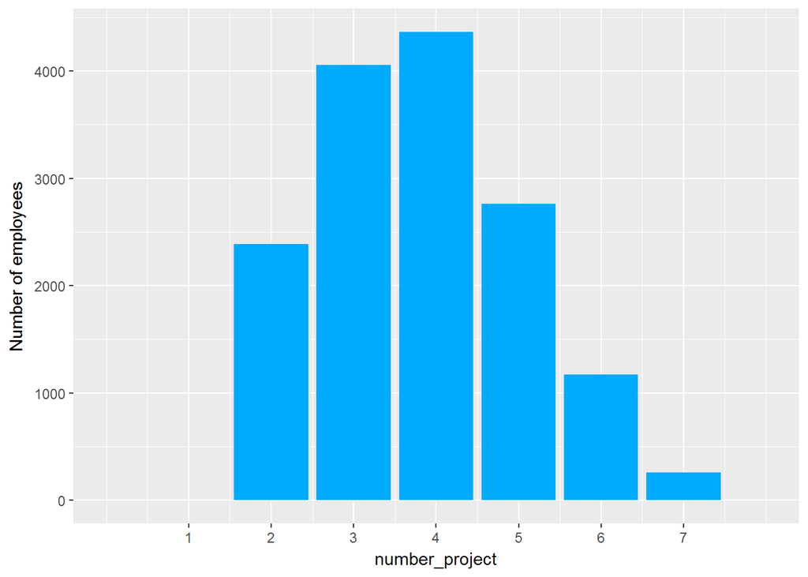

- People in the oraganization have worked in minimum 2 projects and maximum 7 projects.
- Working on 3 or 4 projects is more frequent.

Sumarizing number of projects:

```
##    Min. 1st Qu.  Median    Mean 3rd Qu.    Max.
##   2.000   3.000   4.000   3.803   5.000   7.000
```

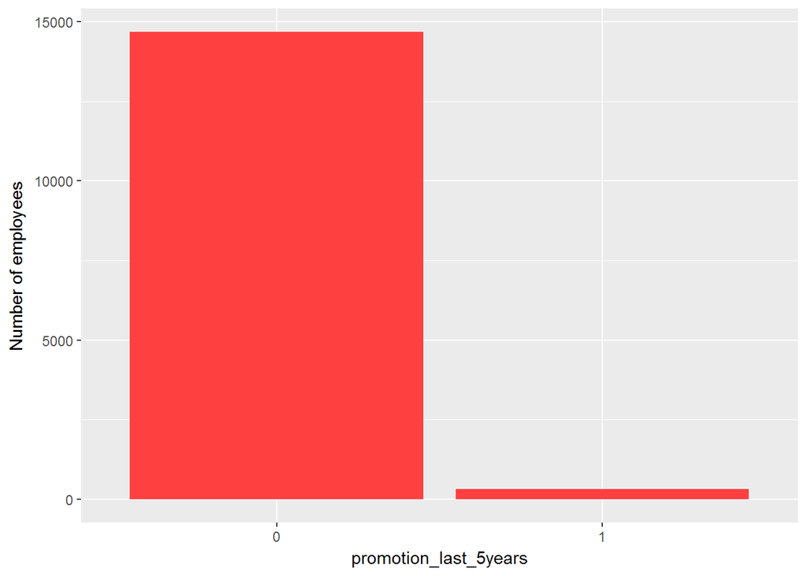

- How many employees were promoted in last 5 years?

```
##     0     1
## 14680   319
```

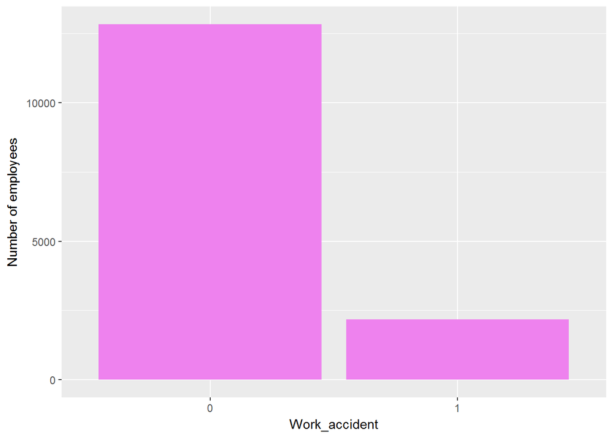

> - How many employees met any accident at work?

```
##     0     1
## 12830  2169
```

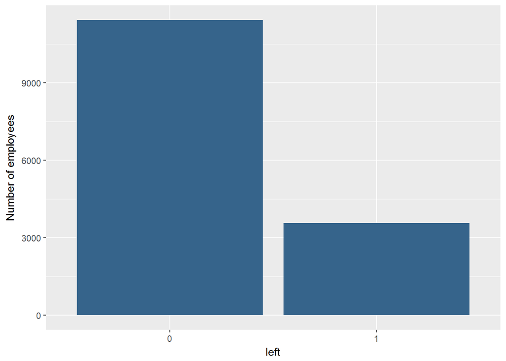

> - How many employees left their job?

```
##
##     0     1
## 11428  3571
```

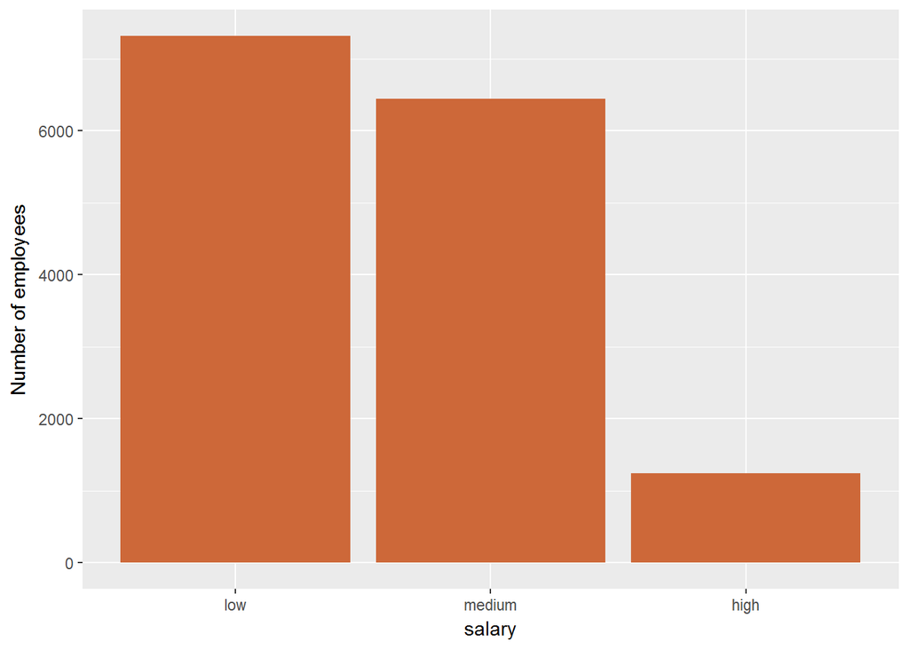

> - What is the salary distibution?

```
##    low medium   high
##   7316   6446   1237
```

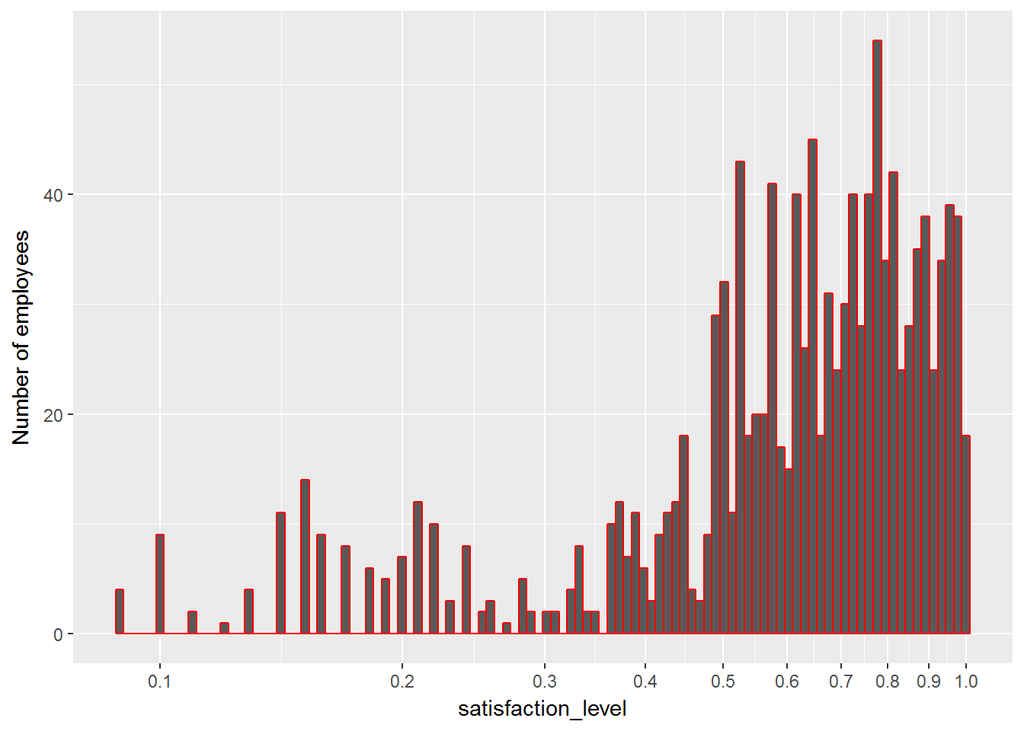

- This shows that satisfaction level of high salaried employees is skewed towardshigher satisfaction level. Although, few are still unhappy.

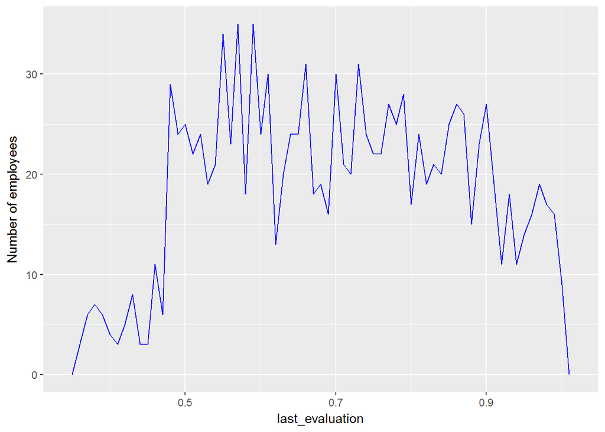

- We all know that the more efficient an employee is, the higher is his salary and visa vera.
- I have subset the data for only those who get higher salary.
- Plotting last_evaluation against their frequency I foundthat most number of high salaried employees score 50% and above.Thus the above assumption is true.

### Those who left:

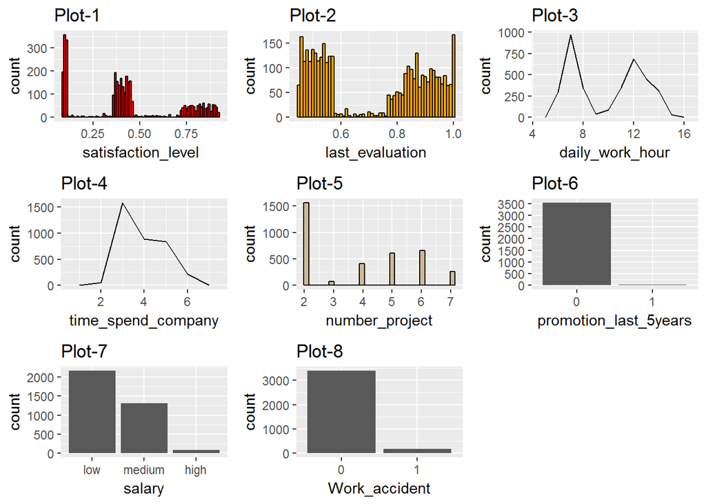

- **Refer Plot-1:** Be it low, mid or high satisfaction level, people have left job in all scenario.
- **Refer Plot-2:** Both high performers and low performers are leaving their jobs.
- **Refer Plot-3:** People who work for 7 hours and those who work 12 hours are more frequent in leaving their jobs.
- **Refer Plot-4:** Most people have left job after spending 3 years or more.However no exits occured after spending 7 years.
- **Refer Plot-5:** Most people leave their job after working on 2 projects with the company.
- **Refer Plot-6:** Among all those who left, only 19 were promoted.Others were not promoted in last five years yet they left.This means promotion does not directly affect one’s exit from the company.
- **Refer Plot-7:** Those who get low or medium amount of salary tend to leave but they are also higher in number.
- **Refer Plot-8:** Many people who left never had a work accident.This means work_accident does not affect employees’ exits.

# Univariate Analysis

### Q1. What is the structure of the dataset?

There are 14999 observations in this dataset with 11 variables like: “satisfaction_level”, “last_evaluation”, “number_project”, “avg_monthly_hours”, “time_spend_company”, “Work_accident”, “left”, “promotion_last_5years”, “department”, “salary”and “daily_work_hour”

**Understanding each variable**:

- satisfaction_level: a feeling of fulfilment or enjoyment that a person derives from their job.
  - It is a continous value measured on the scale of 0-1, in increasing order.
- last_evaluation: assessment of employee’s last performance.
  - It is a continous value measured on the scale of 0-1, in increasing order.
- number_project: number of project a particular employee has worked on.
- avg_monthly_hours: average monthly hours spend by an employee at work.
- daily_work_hours: number of hours an employee works everyday.
  - It is a derived variable, calculated by dividing avg_monthly_hours by 22 assuming 22 is the number of days an employee works in a month.
- time_spend_company: number of years spend in the company.
- work_accident: if an employee met any accident at work.
  - It is a factored variable having ‘0’ false and ‘1’ for true.
- left: if an employee still working or has left his job.
  - It is a factored variable having ‘0’ false and ‘1’ for true.
- promotion_last_5years: if an employee has been promoted in last 5 years or not.
  - It is a factored variable having ‘0’ false and ‘1’ for true.
- department: department to which an employee belongs to, like, sales, account, IT, management etc.
- salary: salary received by each employee, low, medium or high.
  - Out of these variables, salary is an ordered variable having low < medium < high levels.

### Q1. What is the main feature(s) of interest in the dataset?

Almost all the features of this dataset are important to evalaute the tendency of an employee to leave his job. The main features of interest are *‘satisfaction_level’* and ‘*left*’(did he leave or not). All other features contribute to the satisfaction level.

### Q2. What other features in the dataset will help

support the investigation of feature(s) of interest?

Satisfaction_level is influenced by daily_working_hour, number_of_projects, last_evaluation, department in which he works, salary. Thus all these features would help to investigate the faetures of interest.

### Q3. Did you create any new variables from existing

variables in the dataset?

Yes, I have derived daily_work_hour variable by dividing avg_monthly_hours by 22 assuming 22 is the total number of days an employee works in a month.

The assumption of number of days is made on the basis that office is off on weekdays. There are only 5 working days in a week.

The predefined ‘avg_monthly_hours’ does not give a vivid description of the number of hours an employee has to work. Thus, I felt the need of daily_work_hour variable.

### Q4. Of the features you investigated, were there

any unusual distributions? Did you perform any operations on the data to tidy, adjust, or change the form of the data? If so, why did you do this?

We found that there is no employee who left in the first and ninth year of his job. Yes, I factored the variables like ‘left’, ‘promotion_last_5years’, ‘work_accident’ because these have boolean values (0 or 1). Factoring them makes ploting and summaries easier. They have been reconverted into numeric form when required.

The ‘salary’ variable has also been factored as well as ordered in low < medium < high levels.

# Bivariate plots

Let’s compute the corelation taken two variables at a time:

```
##                           left work_accident promotion_last_5years
## left                    1.0000       -0.1500               -0.0620
## work_accident          -0.1500        1.0000                0.0390
## promotion_last_5years  -0.0620        0.0390                1.0000
## hra.satisfaction_level -0.3900        0.0590                0.0260
## hra.last_evaluation     0.0066       -0.0071               -0.0087
## hra.number_project      0.0240       -0.0047               -0.0061
## hra.time_spend_company  0.1400        0.0021                0.0670
## hra.daily_work_hour     0.0700       -0.0100               -0.0038
##                        hra.satisfaction_level hra.last_evaluation
## left                                   -0.390              0.0066
## work_accident                           0.059             -0.0071
## promotion_last_5years                   0.026             -0.0087
## hra.satisfaction_level                  1.000              0.1100
## hra.last_evaluation                     0.110              1.0000
## hra.number_project                     -0.140              0.3500
## hra.time_spend_company                 -0.100              0.1300
## hra.daily_work_hour                    -0.017              0.3400
##                        hra.number_project hra.time_spend_company
## left                               0.0240                 0.1400
## work_accident                     -0.0047                 0.0021
## promotion_last_5years             -0.0061                 0.0670
## hra.satisfaction_level            -0.1400                -0.1000
## hra.last_evaluation                0.3500                 0.1300
## hra.number_project                 1.0000                 0.2000
## hra.time_spend_company             0.2000                 1.0000
## hra.daily_work_hour                0.4100                 0.1200
##                        hra.daily_work_hour
## left                                0.0700
## work_accident                      -0.0100
## promotion_last_5years              -0.0038
## hra.satisfaction_level             -0.0170
## hra.last_evaluation                 0.3400
## hra.number_project                  0.4100
## hra.time_spend_company              0.1200
## hra.daily_work_hour                 1.0000
```

**Correlation Matrix**

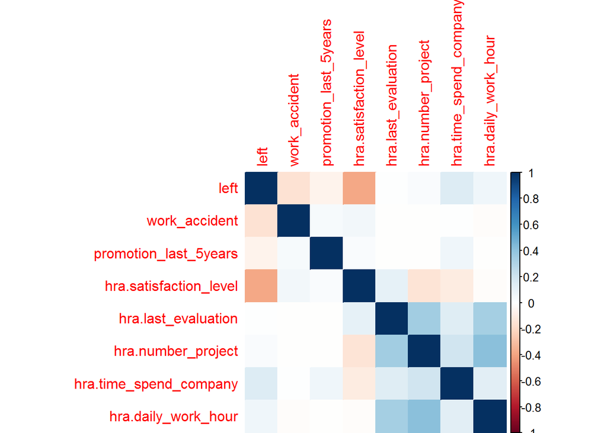

- The above correlation plot visualises the corraltion between two variables. The blue shade reflect positive correlation while brown shade reflects the negative correlation.

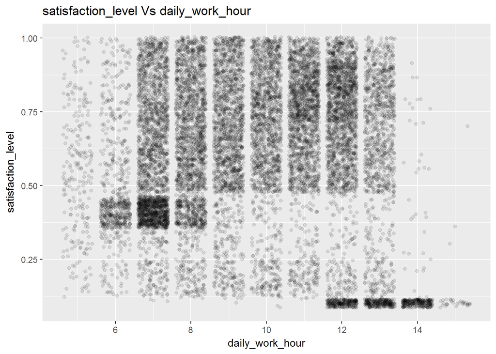

```
## [1] -0.0169797
```

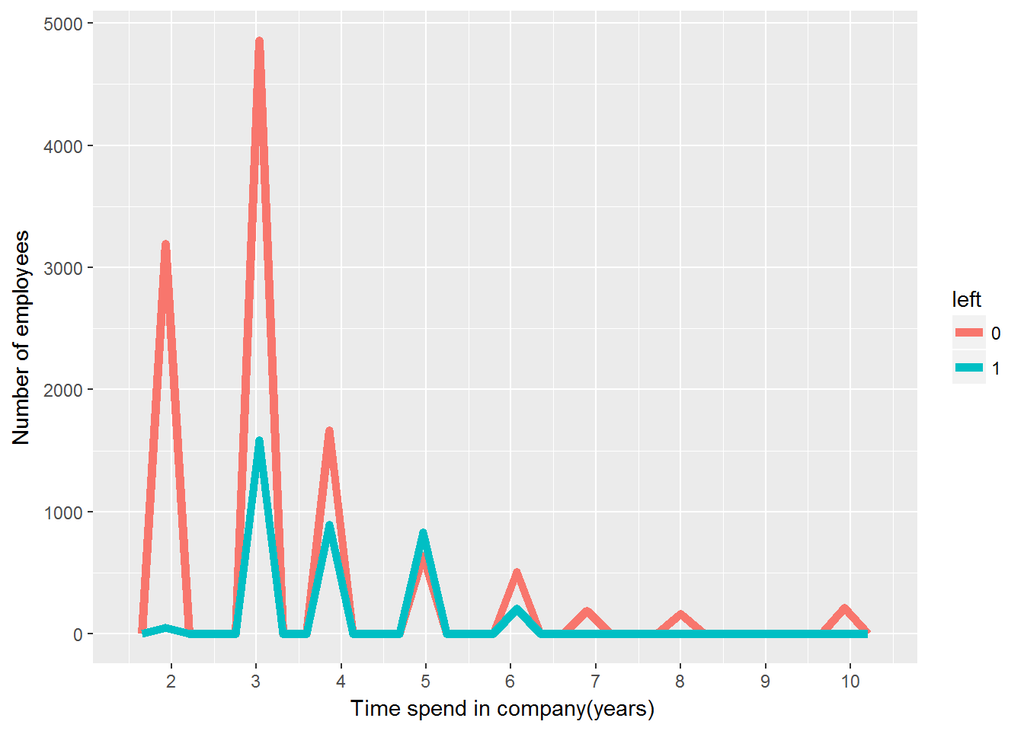

- According to above frequency polygon, employees are more likely to leave their job in the 3rd, 4th, 5th and 6th year of there job. However, no one after spending 7 years in the same company.

[output not shown]

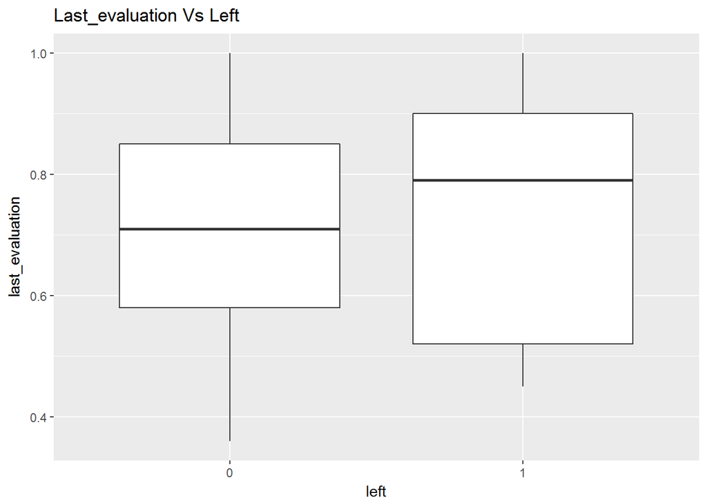

- Employees who left had median of last_evaluation score higher than those who did not leave. This means that efficient employees are leaving.

```
## [1] 0.00656712
```

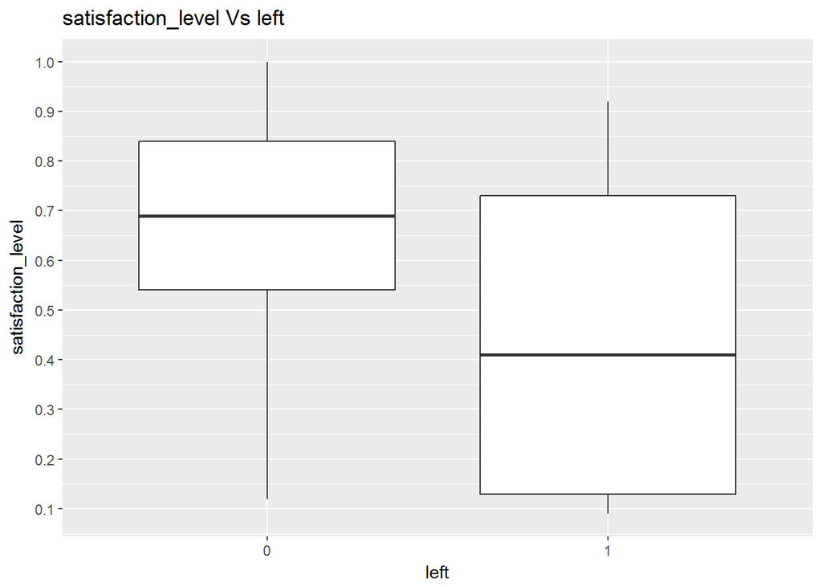

- Median of satisfaction level for those who leave their job is much lower than those who don’t.
- This means that lower satisfaction level contribute to moving on in a job.

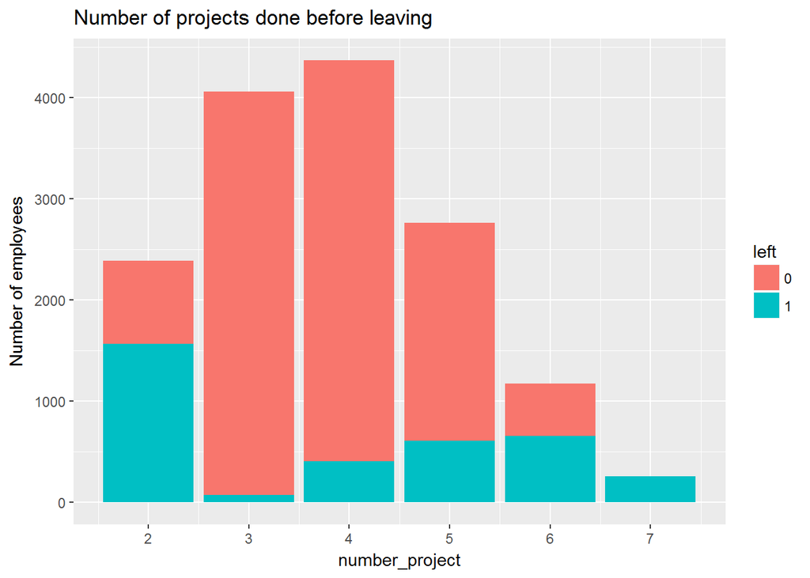

- The correlation between number of project an employee has worked on and whether he left or not is weak but positive. The coeffiecient of correlation is:

```
## [1] 0.02378719
```

- There are more number of exits with increasing number of project(between 3 to 6). *It is suprising that everybody who worked on 7 projects has left.
- Good number of employees who worked on just 2 projects have left the job.

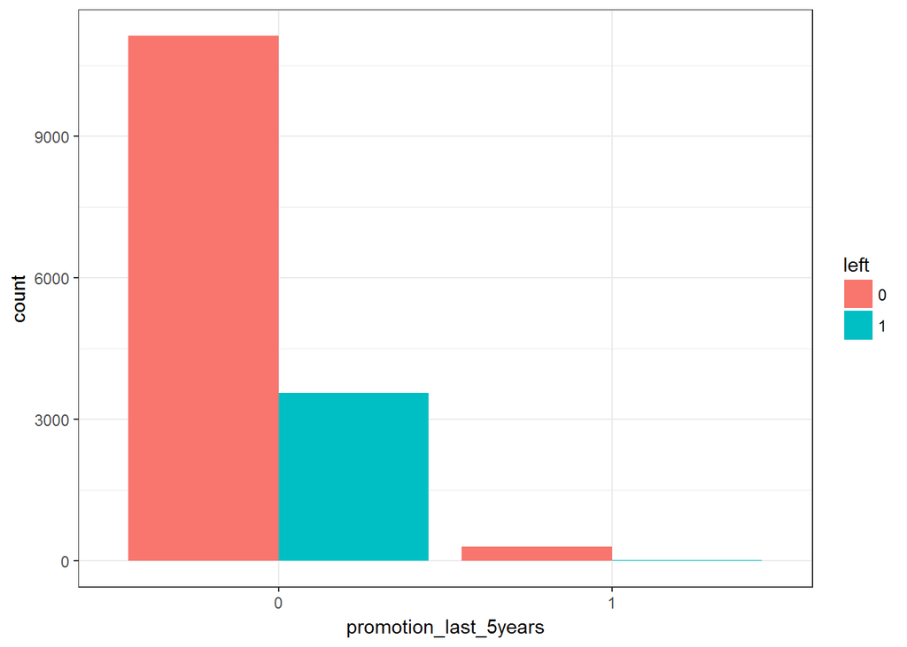

- Considering the entire dataset the correlation between promotion_last_5years and left is negative, if number of promotion increases, number of exits would reduce.
- The above plot shows promotion trend in the company and how exits of employees relates to it.
- The above plot is unable to show the number of people who received promotion but left. So lets adjust the y limits to have a closer look.

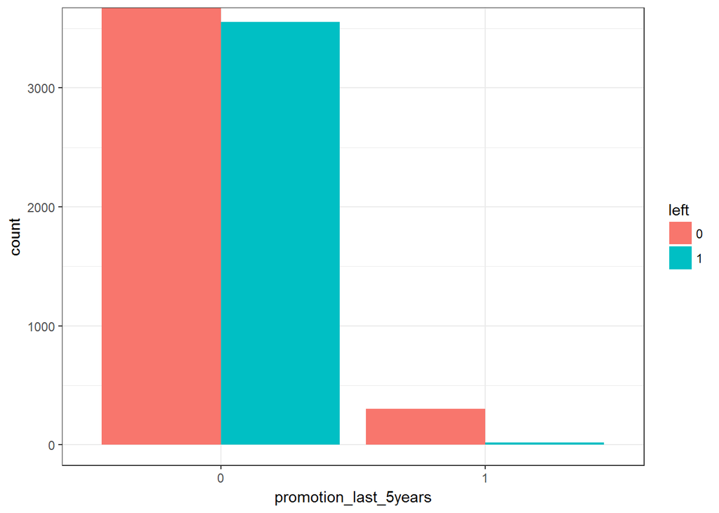

- We can see a fine blue line which shows that due to promotion number of exits were very few.

```
## [1] -0.06178811
```

- The above scatterplot shows that large proportion of people continue to work even after no promotion in last 5 years.
- Does that mean they are satisfied with their job? Let’s find out.

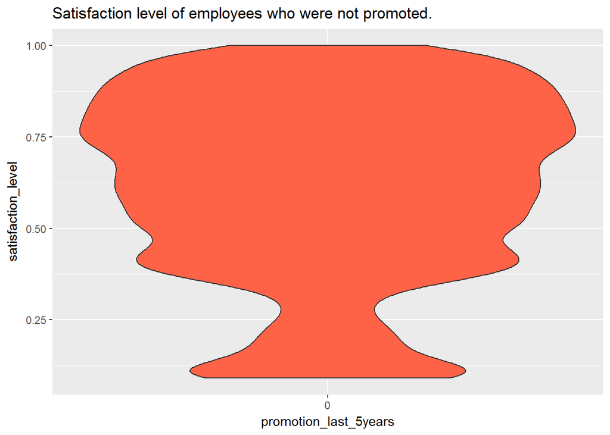

- The above violin plot clearly showing higher volume towards high satisfaction level.
- Promotion and satisfaction level has following correlaion between them:

```
## [1] 0.02560519
```

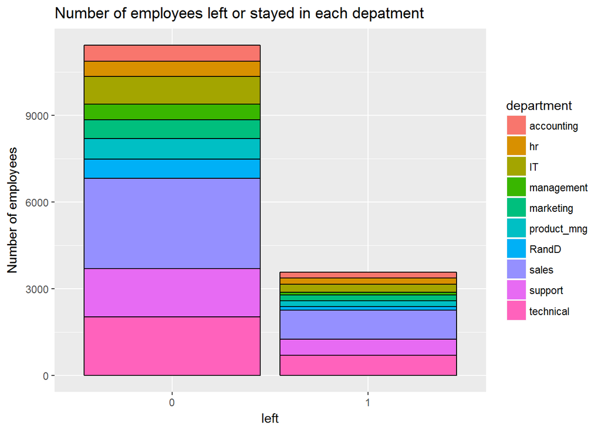

- Number of exits in each deparment is directly propotional to the number of employees working in each department.

```
## hra$department: accounting
##   0   1
## 563 204
## --------------------------------------------------------
## hra$department: hr
##   0   1
## 524 215
## --------------------------------------------------------
## hra$department: IT
##   0   1
## 954 273
## --------------------------------------------------------
## hra$department: management
##   0   1
## 539  91
## --------------------------------------------------------
## hra$department: marketing
##   0   1
## 655 203
## --------------------------------------------------------
## hra$department: product_mng
##   0   1
## 704 198
## --------------------------------------------------------
## hra$department: RandD
##   0   1
## 666 121
## --------------------------------------------------------
## hra$department: sales
##    0    1
## 3126 1014
## --------------------------------------------------------
## hra$department: support
##    0    1
## 1674  555
## --------------------------------------------------------
## hra$department: technical
##    0    1
## 2023  697
```

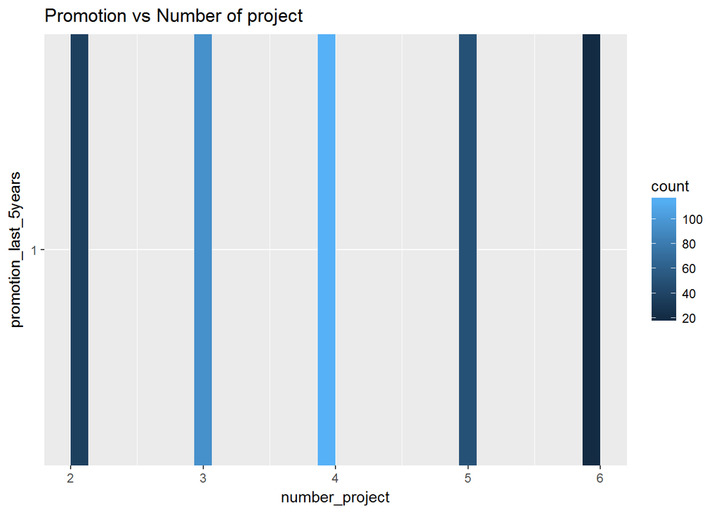

- Most number of people are promoted after working on 4 projects.
- Moderate number of promotions are announced after completing 3 projects.
- Few people are promoted early with just two projects and as late as after doing 6 projects.

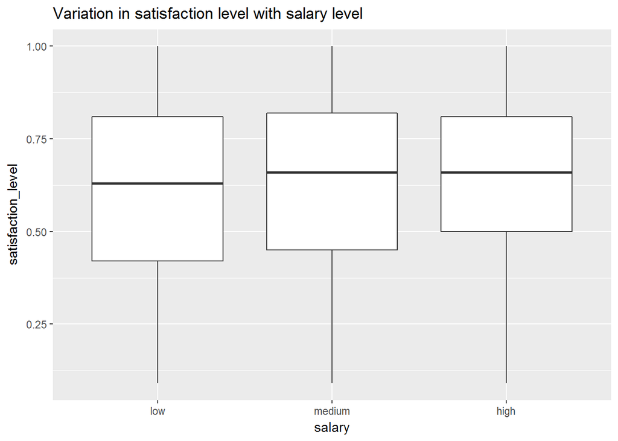

- Mean and median of satisfaction_level are nearly equal across all three salary levels: low, medium, high.
- However the satisfaction levels of lowest 25% of employees is increasing with salary levels

```
## hra$salary: low
##    Min. 1st Qu.  Median    Mean 3rd Qu.    Max.
##  0.0900  0.4200  0.6300  0.6008  0.8100  1.0000
## --------------------------------------------------------
## hra$salary: medium
##    Min. 1st Qu.  Median    Mean 3rd Qu.    Max.
##  0.0900  0.4500  0.6600  0.6218  0.8200  1.0000
## --------------------------------------------------------
## hra$salary: high
##    Min. 1st Qu.  Median    Mean 3rd Qu.    Max.
##  0.0900  0.5000  0.6600  0.6375  0.8100  1.0000
```

** Do people leave their job after encountering work accident? ** Les’s find out!

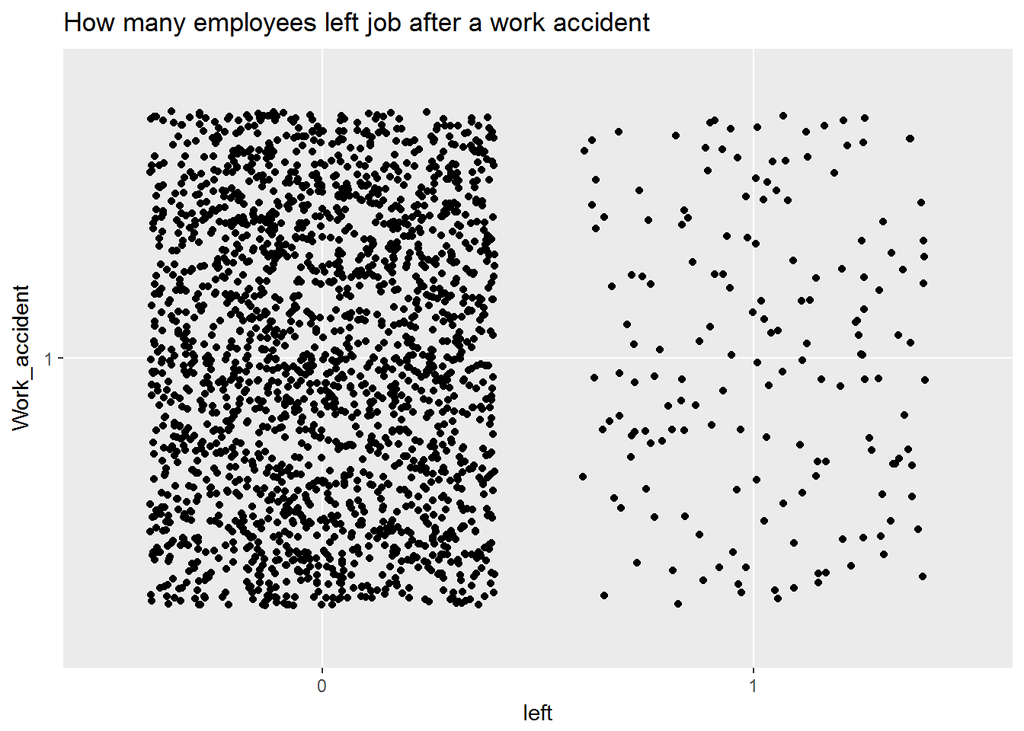

```
## [1] 2169
```

```
## [1] 169
```

```
## [1] 0.07791609
```

- Total number of accidents occured = 2169
- Number of employees who met accidents and left job = 169
- This means 7.7% people left job. Although there can be other reasons too.

# Bivariate Analysis

### Q1. How did the feature(s) of interest vary with other features in the dataset?

- Satisfaction_level and left are my features of interest.
- It is a common assumption that satisfaction level strongly affects the fact that the employee would continue to work or not.I found a negative correlation between these two, which is justifiable.if satisfaction_level decreased, more people leave their jobs and visa versa.

However, I also found that people have left jobs across all satisfaction levels.50 percent of the people who left had satisfaction level below mean.

### Q2. Did you observe any interesting relationships between

the other features (not the main feature(s) of interest)?

*Satisfaction_level and daily working hour is also negatively correlated i.e which is reasonable.* Most people start leaving job on completing 3 years in a company and nobody found leaving job after spending 7 years. Most people leave after working on 2 projects. * Number of promotion_last_5years and number of left are inversely related, i.e,if occurence of promotion increases, number of left decreases. * 50 percentile of employees for each salary levels have almost same satisfaction level.